# Red Wine Quality Exploration by Qiliang Huang

### 挥发性酸度

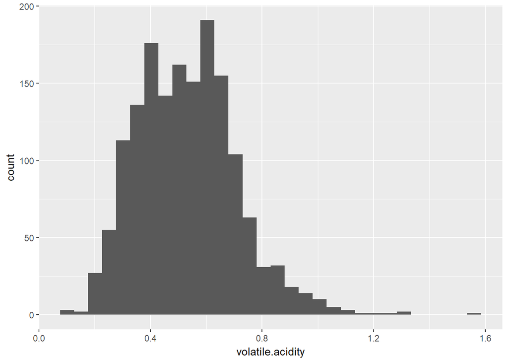

基本上呈正态分布，集中在0.5g/dm^3。

### 柠檬酸度

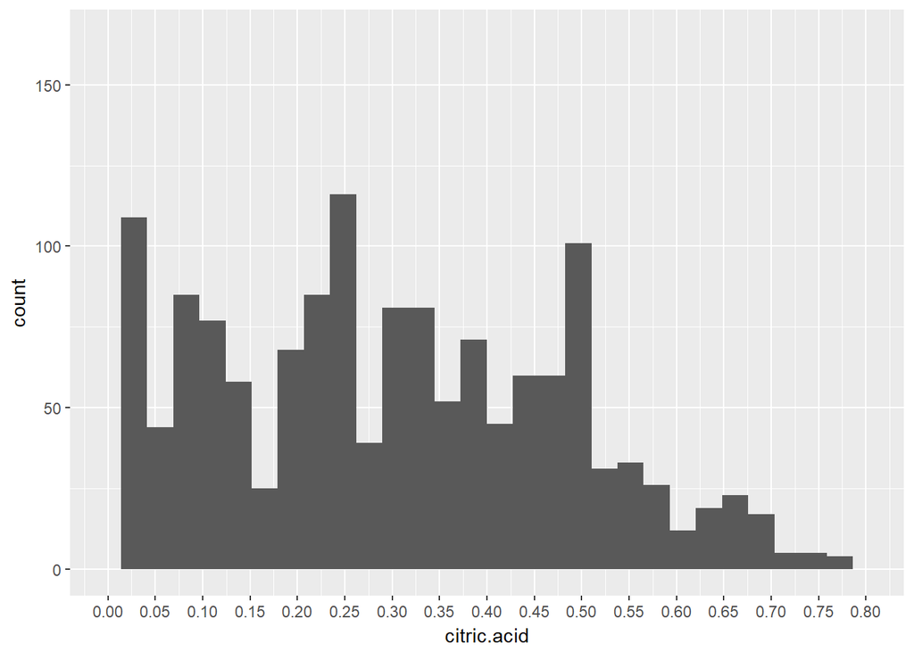

呈现右偏分布。

### 剩余糖含量

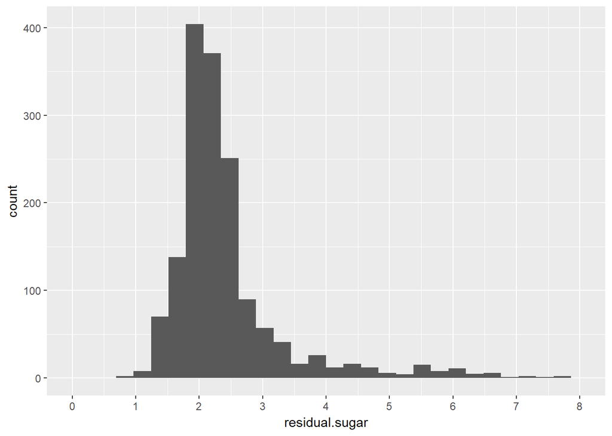

### 含盐量

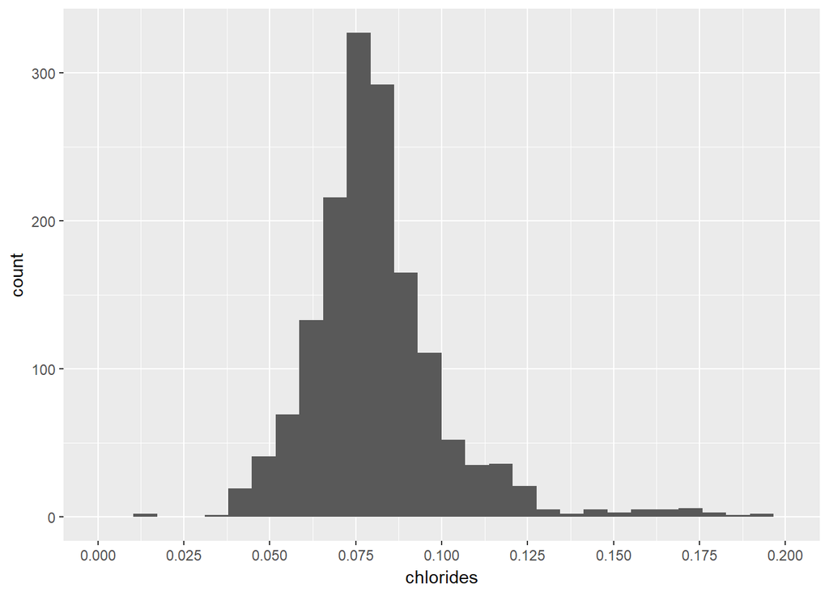

### 游离二氧化硫浓度

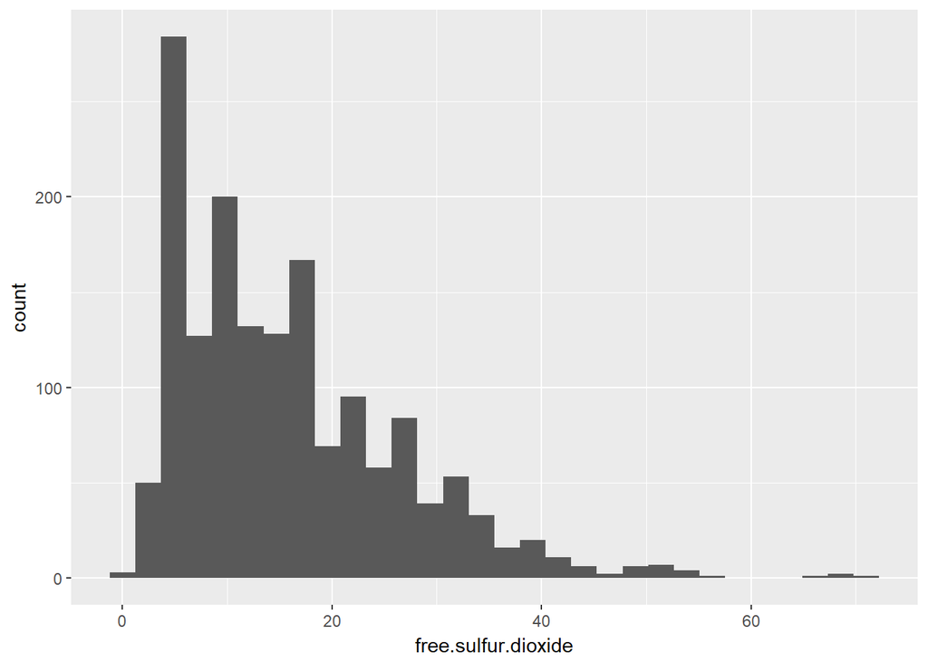

### 全部二氧化硫含量

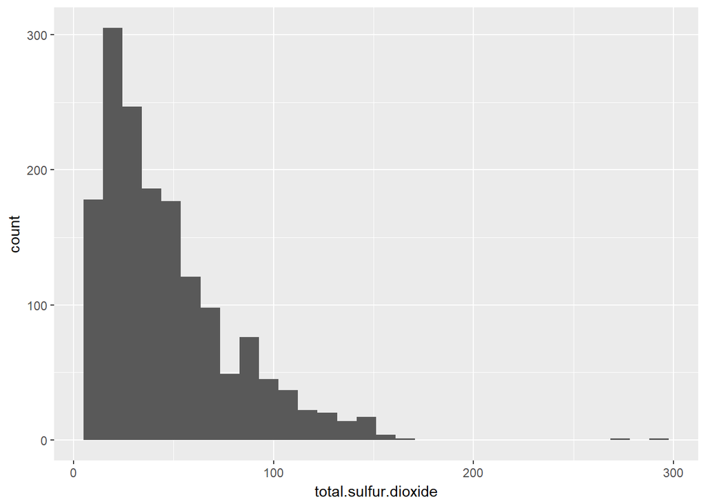

### 红葡萄酒的密度

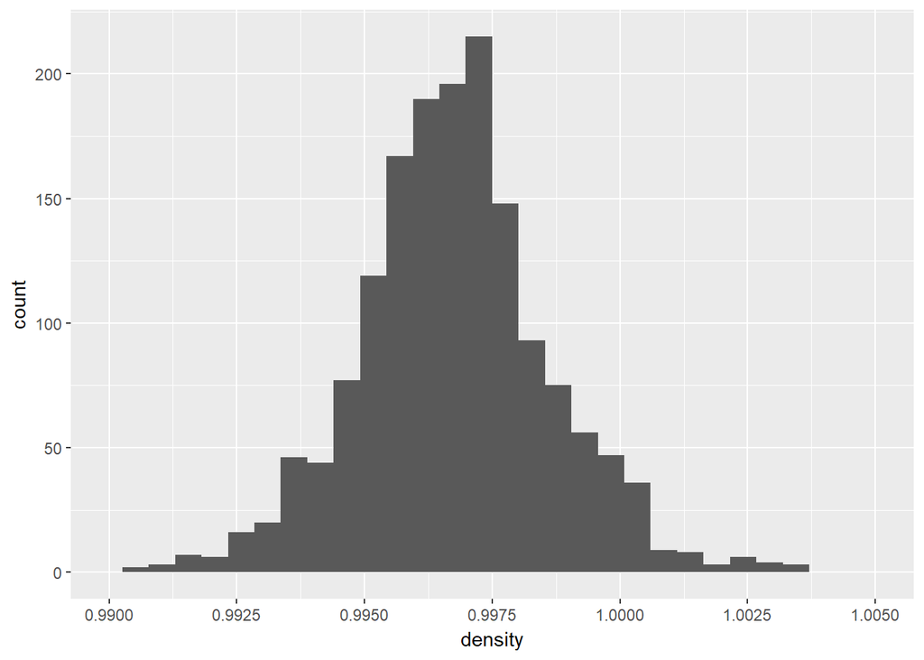

### pH值

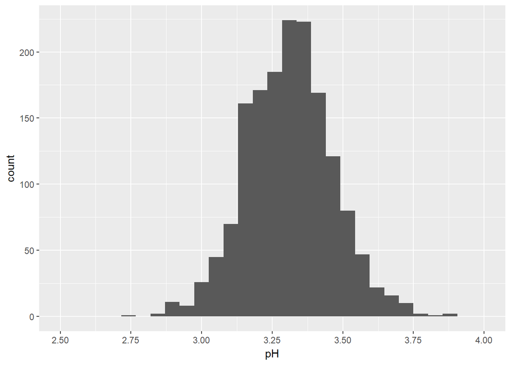